# 2. Confirmation of Bayesian skills

This vignette can be referred to by citing the package:

- Makowski, D., Ben-Shachar, M. S., & Lüdecke, D. (2019). *bayestestR: Describing Effects and their Uncertainty, Existence and Significance within the Bayesian Framework*. Journal of Open Source Software, 4(40), 1541. https://doi.org/10.21105/joss.01541

Now that [**describing and understanding posterior distributions**](https://easystats.github.io/bayestestR/articles/example1.html) of linear regressions is not that mysterious to you, we will take one step back and study some simpler models: **correlations** and *t*-tests.

But before we do that, let us take a moment to remind ourselves and appreciate the fact that **all basic statistical procedures** such as correlations, *t*-tests, ANOVAs, or chi-square tests **are** linear regressions (we strongly recommend [this excellent demonstration](https://lindeloev.github.io/tests-as-linear/)). Nevertheless, these simple models will provide a good pretext to introduce a few more complex indices, such as the **Bayes factor**.

## Correlations

### Frequentist version

Once again, let us begin with a **frequentist correlation** between two continuous variables, the **width** and the **length** of the sepals of some flowers. The data is available in `R` as the `iris` dataset (the same that was used in the [previous tutorial](https://easystats.github.io/bayestestR/articles/example1.html)).

We will compute a Pearson’s correlation test, store the results in an object called `result`, and then display it:

```r
result <- cor.test(iris$Sepal.Width, iris$Sepal.Length)
result
```

```
>
>   Pearson's product-moment correlation
>
> data:  iris$Sepal.Width and iris$Sepal.Length
> t = -1, df = 148, p-value = 0.2
> alternative hypothesis: true correlation is not equal to 0
> 95 percent confidence interval:
>  -0.273  0.044
> sample estimates:
>   cor
> -0.12
```

As you can see in the output, the test actually compared **two** hypotheses: - the **null hypothesis** (*h0*; no correlation), - the **alternative hypothesis** (*h1*; a non-null correlation).

Based on the *p*-value, the null hypothesis cannot be rejected: the correlation between the two variables is **negative but non-significant** ($r = -.12, p > .05$).

### Bayesian correlation

To compute a Bayesian correlation test, we will need the [`BayesFactor`](https://richarddmorey.github.io/BayesFactor/) package (you can install it by running `install.packages("BayesFactor")`). We can then load this package, compute the correlation using the `correlationBF()` function, and store the result.

```r
library(BayesFactor)
result <- correlationBF(iris$Sepal.Width, iris$Sepal.Length)
```

Now, let us run our `describe_posterior()` function on that:

```r
describe_posterior(result)
```

```
> Summary of Posterior Distribution
>
> Parameter | Median |        95% CI |     pd |          ROPE | % in ROPE |         Prior |    BF
> -----------------------------------------------------------------------------------------------
> rho       |  -0.11 | [-0.26, 0.05] | 92.25% | [-0.05, 0.05] |    20.84% | Beta (3 +- 3) | 0.509
```

We see again many things here, but the important indices for now are the **median** of the posterior distribution, `-.11`. This is (again) quite close to the frequentist correlation. We could, as previously, describe the [**credible interval**](https://easystats.github.io/bayestestR/articles/credible_interval.html), the [**pd**](https://easystats.github.io/bayestestR/articles/probability_of_direction.html) or the [**ROPE percentage**](https://easystats.github.io/bayestestR/articles/region_of_practical_equivalence.html), but we will focus here on another index provided by the Bayesian framework, the **Bayes Factor (BF)**.

### Bayes Factor (BF)

We said previously that a correlation test actually compares two hypotheses, a null (absence of effect) with an alternative one (presence of an effect). The [**Bayes factor (BF)**](https://easystats.github.io/bayestestR/articles/bayes_factors.html) allows the same comparison and determines **under which of these two models the observed data are more probable**: a model with the effect of interest, and a null model without the effect of interest. So, in the context of our correlation example, the null hypothesis would be no correlation between the two variables ($h0: \rho = 0$; where $\rho$ stands for Bayesian correlation coefficient), while the alternative hypothesis would be that there is a correlation **different** than 0 - positive or negative ($h1: \rho \neq 0$).

We can use `bayesfactor()` to specifically compute the Bayes factor comparing those models:

```r
bayesfactor(result)
```

```
> Bayes Factors for Model Comparison
>
>     Model         BF
> [2] (rho != 0) 0.509
>
> * Against Denominator: [1] (rho = 0)
> *   Bayes Factor Type: JZS (BayesFactor)
```

We got a *BF* of `0.51`. What does it mean?

Bayes factors are **continuous measures of *relative* evidence**, with a Bayes factor greater than 1 giving evidence in favour of one of the models (often referred to as *the numerator*), and a Bayes factor smaller than 1 giving evidence in favour of the other model (*the denominator*).

> **Yes, you heard that right, evidence in favour of the *null*!**

That’s one of the reason why the Bayesian framework is sometimes considered as superior to the frequentist framework. Remember from your stats lessons, that the *p*-value can only be used to reject *h0*, but not *accept* it. With the **Bayes factor**, you can measure **evidence against - and in favour of - the null**. In other words, in the frequentist framework, if the *p*-value is not significant, we can conclude that **evidence for the effect is absent**, but not that there is **evidence for the absence of the effect**. In Bayesian framework, we can do the latter. This is important since sometimes our hypotheses are about no effect.

BFs representing evidence for the alternative against the null can be reversed using $BF_{01}=1/BF_{10}$ (the *01* and *10* correspond to *h0* against *h1* and *h1* against *h0*, respectively) to provide evidence of the null against the alternative. This improves human readability[^1] in cases where the BF of the alternative against the null is smaller than 1 (i.e., in support of the null).

In our case, `BF = 1/0.51 = 2`, indicates that the data are **2 times more probable under the null compared to the alternative hypothesis**, which, though favouring the null, is considered only [anecdotal evidence against the null](https://easystats.github.io/effectsize/reference/interpret_bf.html).

**And that’s not all!**

### Visualise the Bayes factor

In general, **pie charts are an absolute no-go in data visualisation**, as our brain’s perceptive system heavily distorts the information presented in such way[^2]. Nevertheless, there is one exception: pizza charts.

It is an intuitive way of interpreting the strength of evidence provided by BFs as an amount of surprise.

[figure not shown]

Wagenmakers’ pizza poking analogy. From the great <www.bayesianspectacles.org> blog.

Such “pizza plots” can be directly created through the [`see`](https://github.com/easystats/see) visualisation companion package for `easystats` (you can install it by running `install.packages("see")`):

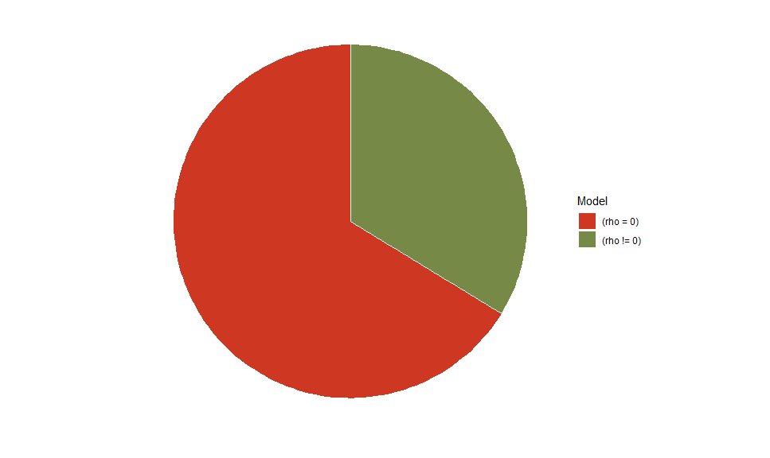

```r
library(see)

plot(bayesfactor(result)) +
  scale_fill_pizza()
```

So, after seeing this pizza, how much would you be surprised by the outcome of a blinded poke?

## *t*-tests

> **“I know that I know nothing, and especially not if *versicolor* and *virginica* differ in terms of their Sepal.Width” - Socrates**.

Time to finally answer this crucial question!

### Versicolor *vs.* virginica

Bayesian *t*-tests can be performed in a very similar way to correlations. As we are particularly interested in two levels of the `Species` factor, *versicolor* and *virginica*. We will start by filtering out from `iris` the non-relevant observations corresponding to the *setosa* specie, and we will then visualise the observations and the distribution of the `Sepal.Width` variable.

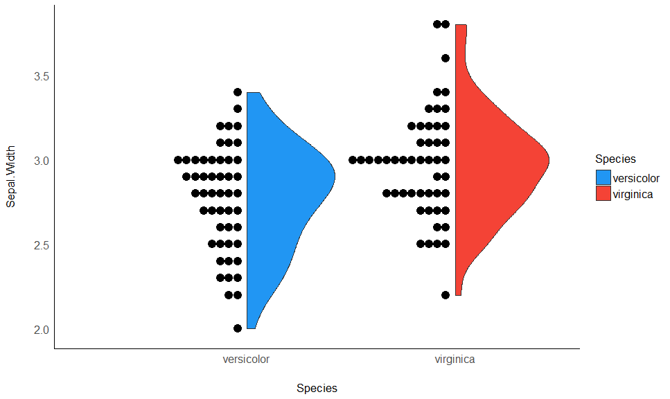

```r
library(dplyr)
library(ggplot2)

# Select only two relevant species
data <- iris %>%
  filter(Species != "setosa") %>%
  droplevels()

# Visualise distributions and observations
data %>%
  ggplot(aes(x = Species, y = Sepal.Width, fill = Species)) +
  geom_violindot(fill_dots = "black", size_dots = 1) +
  scale_fill_material() +
  theme_modern()
```

It *seems* (visually) that *virgnica* flowers have, on average, a slightly higer width of sepals. Let’s assess this difference statistically by using the `ttestBF()` function in the `BayesFactor` package.

### Compute the Bayesian *t*-test

```r
result <- BayesFactor::ttestBF(formula = Sepal.Width ~ Species, data = data)
describe_posterior(result)
```

```
> Summary of Posterior Distribution
>
> Parameter  | Median |       95% CI |     pd |          ROPE | % in ROPE |              Prior |    BF
> ----------------------------------------------------------------------------------------------------
> Difference |   0.19 | [0.06, 0.31] | 99.75% | [-0.03, 0.03] |        0% | Cauchy (0 +- 0.71) | 17.72
```

Keep that in mind as we will see another way of investigating this question.

## Logistic Model

A hypothesis for which one uses a *t*-test can also be tested using a binomial model (*e.g.*, a **logistic model**). Indeed, it is possible to reformulate the following hypothesis, “*there is an important difference in this variable between the two groups*” with the hypothesis “*this variable is able to discriminate between (or classify) the two groups*.” However, these models are much more powerful than a *t*-test.

In the case of the difference of `Sepal.Width` between *virginica* and *versicolor*, the question becomes, *how well can we classify the two species using only* `Sepal.Width`.

### Fit the model

```r
library(rstanarm)

model <- stan_glm(Species ~ Sepal.Width, data = data, family = "binomial", refresh = 0)
```

### Visualise the model

Using the [`modelbased`](https://github.com/easystats/modelbased) package.

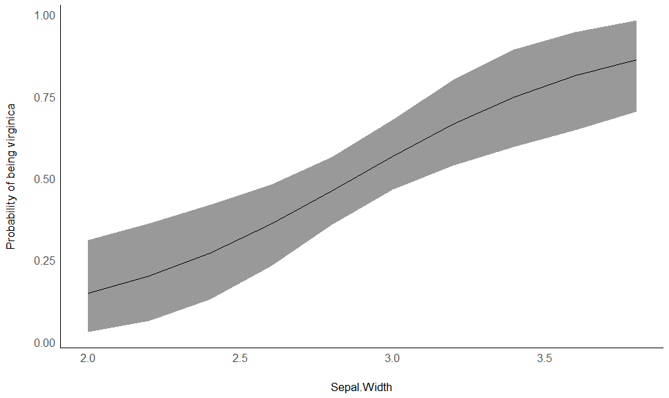

```r
library(modelbased)

vizdata <- estimate_relation(model)

ggplot(vizdata, aes(x = Sepal.Width, y = Predicted)) +
  geom_ribbon(aes(ymin = CI_low, ymax = CI_high), alpha = 0.5) +
  geom_line() +
  ylab("Probability of being virginica") +
  theme_modern()
```

### Performance and Parameters

Once again, we can extract all indices of interest for the posterior distribution using our old pal `describe_posterior()`.

```r
describe_posterior(model, test = c("pd", "ROPE", "BF"))
```

```
> Summary of Posterior Distribution
>
> Parameter   | Median |          95% CI |     pd |          ROPE | % in ROPE |  Rhat |     ESS |    BF
> -----------------------------------------------------------------------------------------------------
> (Intercept) |  -6.15 | [-10.26, -2.13] | 99.92% | [-0.18, 0.18] |        0% | 1.001 | 2651.00 |  7.23
> Sepal.Width |   2.13 | [  0.77,  3.60] | 99.95% | [-0.18, 0.18] |        0% | 1.001 | 2639.00 | 20.31
```

```r
library(performance)

model_performance(model)
```

```
> # Indices of model performance
>
> ELPD    | ELPD_SE |   LOOIC | LOOIC_SE |    WAIC |    R2 |  RMSE | Sigma | Log_loss | Score_log | Score_spherical
> -----------------------------------------------------------------------------------------------------------------
> -66.265 |   3.071 | 132.530 |    6.142 | 132.519 | 0.099 | 0.477 | 1.000 |    0.643 |   -34.666 |           0.014
```

### Visualise the indices

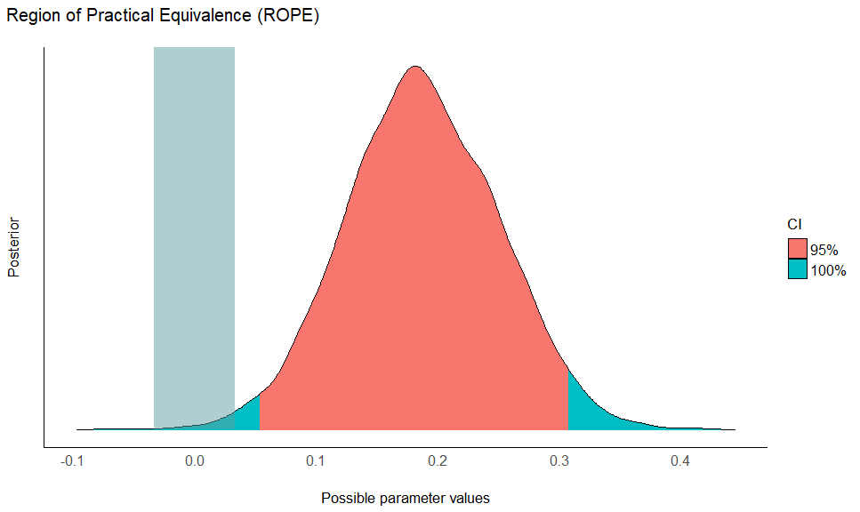

```r
library(see)

plot(rope(result))
```

### Diagnostic Indices

About diagnostic indices such as Rhat and ESS.

[^1]: If the effect is really strong, the BF values can be extremely high. So don’t be surprised if you see BF values that have been log-transformed to make them more human readable.
[^2]: An exception would be when the pie slices are well-labeled so that our brain’s perception system does not have to do the decoding work.